# NBA Players Return

## Thunder

**PG: Tyrese Maxey** (76ers)  
**SG: James Harden** (76ers)  
**SF: Josh Giddey** (Thunder)  
**PF: Kevin Durant** (Nets)  
**C: Chet Holmgren** (Thunder)  
6: Russell Westbrook (Lakers)  
7: Cameron Payne (Suns)  
8: Reggie Jackson (Clippers)  
9: Lu Dort (Thunder)

Extra Players:  
- Alex Caruso (Bulls)  
- Monte Morris (Wizards)  
- Jalen McDaniels (Hornets)  
- Brandon Clarke (Grizzlies)

I would tell the Thunder to stop trading but this is a whole bunch of issues, be it the Harden saga, all things KD, or just having multiple top 5 picks with KD Russ and Harden. This would be a very good team (although realistically they are just guards if KD and/or Chet get hurt (which they do a lot)) though all things considered.

This time I’ll set the over-under for improvement at 20 games.

```r
thunder = players_2022[grepl("OKC", players_2022$slugTeamsBREF),]
most_played_thunder = tail(thunder[order(thunder$minutesTotals),], 9)

thunder_new = rbind(players_2022[grepl("Tyrese Maxey", players_2022$namePlayer),],
                    players_2022[grepl("James Harden", players_2022$namePlayer),],
                    players_2022[grepl("Josh Giddey", players_2022$namePlayer),],
                    players_2022[grepl("Kevin Durant", players_2022$namePlayer),],
                    players_2022[grepl("Alex Caruso", players_2022$namePlayer),],
                    players_2022[grepl("Russell Westbrook", players_2022$namePlayer),],
                    players_2022[grepl("Cameron Payne", players_2022$namePlayer),],
                    players_2022[grepl("Reggie Jackson", players_2022$namePlayer),],
                    players_2022[grepl("Luguentz Dort", players_2022$namePlayer),])

wins_data_thunder = data.frame (
  Team = c("Original", "New", "Difference"),
  Wins = c(sum(most_played_thunder$ratioWS), sum(thunder_new$ratioWS), sum(thunder_new$ratioWS) - sum(most_played_thunder$ratioWS)))

kable(wins_data_thunder)
```

| Team | Wins |
| --- | --- |
| Original | 13.2 |
| New | 31.1 |
| Difference | 17.9 |

I will note I had no stats for Chet to look at, so I just took the next best player the Thunder had in Caruso. But even then they sadly could not reach the over. only 31 wins is somewhat shocking to me given that big 3 they have, and I didn’t think the depth was *that* bad (this is foreshadowing)

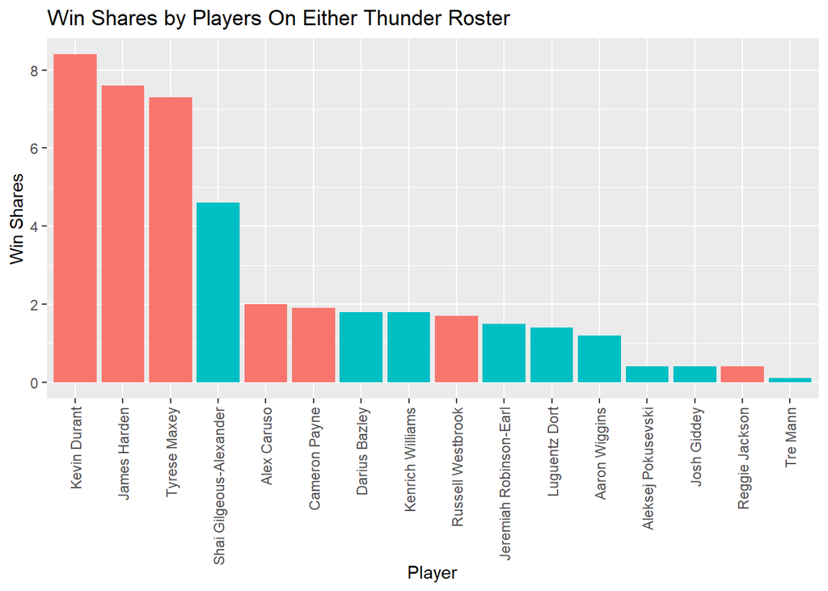

```r
combined = rbind(most_played_thunder, thunder_new)
combined = cbind(combined, original_team)
temp = data.table(combined)
combined = unique(temp, by = 'namePlayer')

ggplot(combined, aes(x=reorder(namePlayer, -ratioWS), y=ratioWS, fill=original_team)) +
  geom_bar(stat="identity") +
  theme(legend.position = "none", axis.text.x = element_text(angle = 90, vjust = 0.5, hjust=1)) +
  ggtitle("Win Shares by Players On Either Thunder Roster") +
  labs(y="Win Shares", x = "Player")
```

The depth was *that* bad goddamn. I have no clue how that actually competed with the original Thunder’s, who competed for the first pick’s, depth. Still KD + Maxey + Harden far and away better than anything the Thunder had before.

Final verdict: Improved by a lot.

## Spurs

**PG: Dejounte Murray** (Hawks)  
**SG: Devin Vassell** (Spurs)  
**SF: Lonnie Walker IV** (Lakers)  
**PF: Kyle Anderson** (Wolves)  
**C: Jeremy Sochan** (Spurs)  
6: Derrick White (Celtics)  
7: Tre Jones (Spurs)  
8: Drew Eubanks (Blazers)  
9: JaMychal Green (Warriors)

Extra Players:  
- George Hill (Bucks)

Just last year’s Spurs that somehow made the play-in (the Lakers were **REALLY** bad) but I feel slightly more confident since Lonnie Walker has actual attention on him.

Are they really the same though?

```r
spurs = players_2022[grepl("SAS", players_2022$slugTeamsBREF),]
most_played_spurs = tail(spurs[order(spurs$minutesTotals),], 9)
```

```r
spurs_new = rbind(players_2022[grepl("Dejounte Murray", players_2022$namePlayer),],
                    players_2022[grepl("Devin Vassell", players_2022$namePlayer),],
                    players_2022[grepl("Lonnie Walker IV", players_2022$namePlayer),],
                    players_2022[grepl("Kyle Anderson", players_2022$namePlayer),],
                    temp,
                    players_2022[grepl("Derrick White", players_2022$namePlayer),],
                    players_2022[grepl("Tre Jones", players_2022$namePlayer),],
                    players_2022[grepl("Drew Eubanks", players_2022$namePlayer),],
                    players_2022[grepl("JaMychal Green", players_2022$namePlayer),])

wins_data_spurs = data.frame (
  Team = c("Original", "New", "Difference"),
  Wins = c(sum(most_played_spurs$ratioWS), sum(spurs_new$ratioWS), sum(spurs_new$ratioWS) - sum(most_played_spurs$ratioWS)))

kable(wins_data_spurs)
```

| Team | Wins |
| --- | --- |
| Original | 37.000000 |
| New | 28.686957 |
| Difference | -8.313043 |

No, in fact they’re somehow worse, but let’s see why.

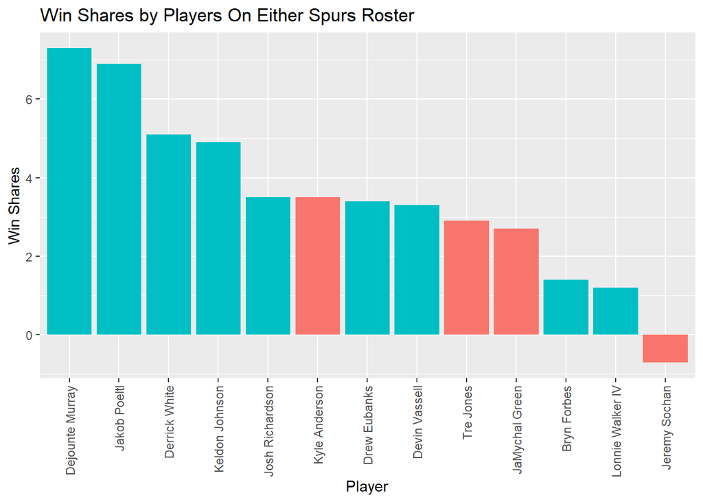

```r
combined = rbind(most_played_spurs, spurs_new)
combined = cbind(combined, original_team)
temp = data.table(combined)
combined = unique(temp, by = 'namePlayer')

ggplot(combined, aes(x=reorder(namePlayer, -ratioWS), y=ratioWS, fill=original_team)) +
  geom_bar(stat="identity") +
  theme(legend.position = "none", axis.text.x = element_text(angle = 90, vjust = 0.5, hjust=1)) +
  ggtitle("Win Shares by Players On Either Spurs Roster") +
  labs(y="Win Shares", x = "Player")
```

Poeltl was much more valuable than I expected. I have now also learned Lonnie Walker just wasn’t good last year, as he already has a similar amount of win shares just 20 games in.

Final verdict: Slightly worse.

## Rockets

**PG: Gary Payton II** (Blazers)  
**SG: Jalen Green** (Rockets)  
**SF: Marcus Morris** (Clippers)  
**PF: Jabari Smith Jr.** (Rockets)  
**C: Clint Capela** (Hawks)  
6: Nicolas Batum (Clippers)  
7: Kenyon Martin Jr. (Rockets)  
8: Andrew Nembhard (Pacers)  
9: Larry Nance Jr. (Pels)

Extra Players:  
- Juan Hernangomez (Raptors)  
- Robert Covington (Clippers)  
- Rudy Gay (Jazz)  
- Jae’Sean Tate (Rockets)

Not even this dumb idea can save the Rockets, who are still not good.

At least I think…

```r
rockets = players_2022[grepl("HOU", players_2022$slugTeamsBREF),]
most_played_rockets = tail(rockets[order(rockets$minutesTotals),], 9)
```

```r
rockets_new = rbind(players_2022[grepl("Gary Payton II", players_2022$namePlayer),],
                    temp2,
                    players_2022[grepl("Marcus Morris", players_2022$namePlayer),],
                    players_2022[grepl("Jalen Green", players_2022$namePlayer),],
                    temp,
                    players_2022[grepl("Clint Capela", players_2022$namePlayer),],
                    players_2022[grepl("Nicolas Batum", players_2022$namePlayer),],
                    players_2022[grepl("Kenyon Martin Jr.", players_2022$namePlayer),],
                    players_2022[grepl("Larry Nance Jr.", players_2022$namePlayer),])

wins_data_rockets = data.frame (
  Team = c("Original", "New", "Difference"),
  Wins = c(sum(most_played_rockets$ratioWS), sum(rockets_new$ratioWS), sum(rockets_new$ratioWS) - sum(most_played_rockets$ratioWS)))

kable(wins_data_rockets)
```

| Team | Wins |
| --- | --- |
| Original | 21.50000 |
| New | 31.28956 |
| Difference | 9.78956 |

The Rockets were much better, but let’s fully see how.

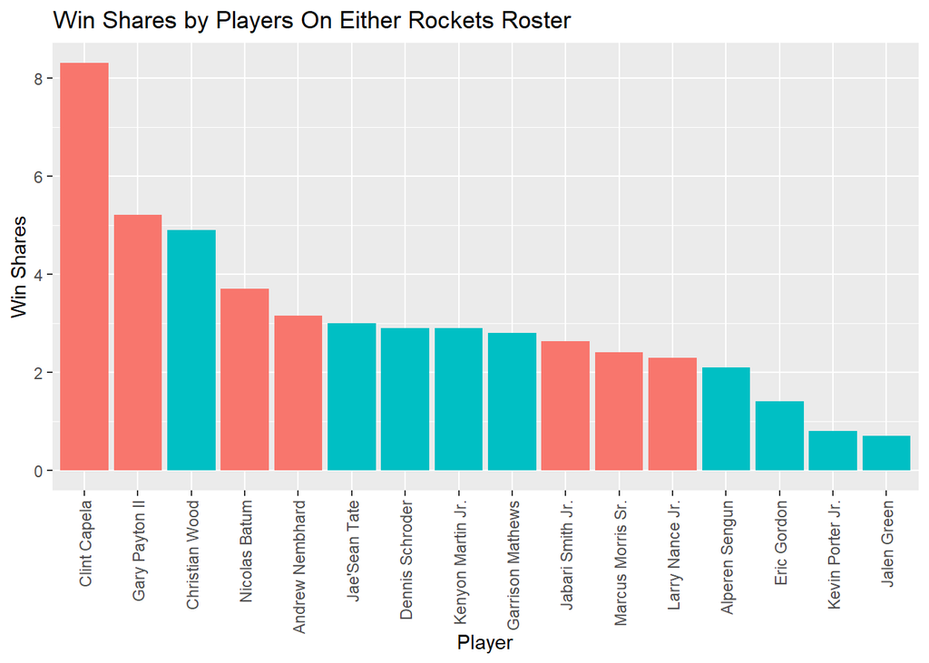

```r
combined = rbind(most_played_rockets, rockets_new)
combined = cbind(combined, original_team)
temp = data.table(combined)
combined = unique(temp, by = 'namePlayer')

ggplot(combined, aes(x=reorder(namePlayer, -ratioWS), y=ratioWS, fill=original_team)) +
  geom_bar(stat="identity") +
  theme(legend.position = "none", axis.text.x = element_text(angle = 90, vjust = 0.5, hjust=1)) +
  ggtitle("Win Shares by Players On Either Rockets Roster") +
  labs(y="Win Shares", x = "Player")
```

Clint Capela carries.

Final verdict: Slightly better.

# Initial Reactions/Rankings

Before looking at any stats. I decided to place the teams into tiers of how good I thought they were and if I thought they improved or got worse.

For **how good they are:**

Chip: Nuggets, Cavs, Raptors, Thunder, 76ers, Pacers  
Playoffs: Nets, Hornets, Pelicans, Knicks, T-Wolves, Bulls, Grizzlies  
Mid (Maybe Play-in): Lakers, Kings, Wizards, Magic, Celtics, Blazers, Mavericks, Spurs  
Goofy: Warriors, Hawks, Bucks, Suns, Clippers  
Tank for Wemby lmao: Heat, Pistons, Rockets, Jazz

For **if they improved or not:**

PLEASE NEVER TRADE AGAIN: Pacers, Nets, Raptors, Hornets, Nuggets, T-Wolves, Thunder  
Slightly Better: Cavs, 76ers, Knicks, Magic, Pelicans, Spurs, Lakers  
Same-ish: Bulls, Wizards, Pistons, Kings  
Slightly Worse: Bucks, Hawks, Blazers, Rockets  
CARRIED BY TRADES: Warriors, Celtics, Heat, Grizzlies, Suns, Clippers, Mavericks, Jazz

First reaction to the lists that you can tell how much a team trades based off whether it’s in an outer tier for the second list or not. I think the only exception to this is the Bulls and Lakers, who despite trading many times are just around the same overall but with very different rosters.

# How Each Team Faired Statistically

Sorting by the difference in wins, we see:

```r
kable(final_results[order(-final_results$Difference),])
```

|  | Team | Initial_Wins | Final_Wins | Difference |
| --- | --- | --- | --- | --- |
| 26 | Thunder | 13.2 | 31.10000 | 17.9000000 |
| 17 | Nuggets | 39.9 | 55.70000 | 15.8000000 |
| 21 | Raptors | 44.0 | 54.60000 | 10.6000000 |
| 22 | Rockets | 21.5 | 31.28956 | 9.7895604 |
| 13 | Lakers | 27.9 | 36.10000 | 8.2000000 |
| 14 | Magic | 18.0 | 25.66667 | 7.6666667 |
| 3 | Bulls | 34.5 | 39.70000 | 5.2000000 |
| 29 | Timberwolves | 39.8 | 44.90000 | 5.1000000 |
| 20 | Pistons | 18.5 | 23.20000 | 4.7000000 |
| 19 | Pelicans | 32.6 | 35.40000 | 2.8000000 |
| 4 | Cavaliers | 41.6 | 43.10000 | 1.5000000 |
| 27 | Warriors | 45.3 | 45.54286 | 0.2428571 |
| 11 | Kings | 31.0 | 30.69231 | -0.3076923 |
| 6 | Grizzlies | 44.8 | 43.70000 | -1.1000000 |
| 28 | Wizards | 33.9 | 31.26800 | -2.6320000 |
| 1 | Trailblazers | 24.1 | 20.63103 | -3.4689655 |
| 7 | Hawks | 39.2 | 33.43846 | -5.7615385 |
| 23 | 76ers | 49.5 | 43.55714 | -5.9428571 |
| 18 | Pacers | 28.1 | 20.91789 | -7.1821114 |
| 5 | Clippers | 33.5 | 25.33846 | -8.1615385 |
| 24 | Spurs | 37.0 | 28.68696 | -8.3130435 |
| 9 | Hornets | 44.3 | 35.10000 | -9.2000000 |
| 12 | Knicks | 34.6 | 23.38000 | -11.2200000 |
| 15 | Mavericks | 47.8 | 32.10000 | -15.7000000 |
| 10 | Jazz | 47.9 | 30.73793 | -17.1620690 |
| 8 | Heat | 45.6 | 28.30000 | -17.3000000 |
| 2 | Bucks | 44.3 | 25.11111 | -19.1888889 |
| 16 | Nets | 38.7 | 18.30000 | -20.4000000 |
| 25 | Suns | 49.9 | 20.38571 | -29.5142857 |

Sorting by new wins, we see:

```r
kable(final_results[order(-final_results$Final_Wins),])
```

|  | Team | Initial_Wins | Final_Wins | Difference |
| --- | --- | --- | --- | --- |
| 17 | Nuggets | 39.9 | 55.70000 | 15.8000000 |
| 21 | Raptors | 44.0 | 54.60000 | 10.6000000 |
| 27 | Warriors | 45.3 | 45.54286 | 0.2428571 |
| 29 | Timberwolves | 39.8 | 44.90000 | 5.1000000 |
| 6 | Grizzlies | 44.8 | 43.70000 | -1.1000000 |
| 23 | 76ers | 49.5 | 43.55714 | -5.9428571 |
| 4 | Cavaliers | 41.6 | 43.10000 | 1.5000000 |
| 3 | Bulls | 34.5 | 39.70000 | 5.2000000 |
| 13 | Lakers | 27.9 | 36.10000 | 8.2000000 |
| 19 | Pelicans | 32.6 | 35.40000 | 2.8000000 |
| 9 | Hornets | 44.3 | 35.10000 | -9.2000000 |
| 7 | Hawks | 39.2 | 33.43846 | -5.7615385 |
| 15 | Mavericks | 47.8 | 32.10000 | -15.7000000 |
| 22 | Rockets | 21.5 | 31.28956 | 9.7895604 |
| 28 | Wizards | 33.9 | 31.26800 | -2.6320000 |
| 26 | Thunder | 13.2 | 31.10000 | 17.9000000 |
| 10 | Jazz | 47.9 | 30.73793 | -17.1620690 |
| 11 | Kings | 31.0 | 30.69231 | -0.3076923 |
| 24 | Spurs | 37.0 | 28.68696 | -8.3130435 |
| 8 | Heat | 45.6 | 28.30000 | -17.3000000 |
| 14 | Magic | 18.0 | 25.66667 | 7.6666667 |
| 5 | Clippers | 33.5 | 25.33846 | -8.1615385 |
| 2 | Bucks | 44.3 | 25.11111 | -19.1888889 |
| 12 | Knicks | 34.6 | 23.38000 | -11.2200000 |
| 20 | Pistons | 18.5 | 23.20000 | 4.7000000 |
| 18 | Pacers | 28.1 | 20.91789 | -7.1821114 |
| 1 | Trailblazers | 24.1 | 20.63103 | -3.4689655 |
| 25 | Suns | 49.9 | 20.38571 | -29.5142857 |
| 16 | Nets | 38.7 | 18.30000 | -20.4000000 |

# Final Rankings

# Discussion: Scientific Flaws and Methodology

Do I recommend reading this if you’re not a stats nerd or you had no issues with how I calculated wins, no, but if any of those two things applied to you here’s this information in a Q&A format.

Why Win Shares?

I Initially wanted to calculate the points for and against for each NBA team then use pythagorean wins, but I realized it would be very difficult to interpret a player’s value on a new team with a new system. It’s not like sports like baseball where players can feel very plug and play, some players just don’t work well together in the NBA. A roster of the best 3-point shooters at each position, although valuable at face value, wouldn’t mesh well together on the court. This is why I decided to use win shares, as it’s a simple interpretation of a player’s “value.”

Why use last year instead of what has happened this year?

This one is pretty simple. Only 20-30 something games have happened so far this year. We’re not even half way in and a lot can happen. A player can get injured for the rest of the season (See: AD, Cade or Curry), or just get worse as the season goes on. If I look at last year, I get a full season to interpret stats. But even then there’s some other small issues I’ll touch on:  
1. Players that missed the whole season. - Although this deflates their stats it’s something important to consider for their value year on year given their injury prone-ness.  
2. Rookies for this season. - Something I should’ve accounted for, as rookies in my study acted as a new player instead of still being on their original teams, though this didn’t have too much of an effect in my opinion as it only effected a few teams and most rookies tend to have very low win shares, barely affecting the totals.  
3. Projecting players for the 2023 season. - This one is fully on me, as I interpreted a player’s 2023 value as if they played 82 games, which isn’t realistic, instead of taking the proportion of games they’ve played to far and projecting it to a 82 games season.

How Did You Choose the Rotations You Did?

It was all personal decision, I was the head coach for each team. I tried to look at most minutes played to affect bench as well, but simply taking the 9 most valuable players would be unfair, as that’s not what I did for the original teams. I also didn’t want to take the 9 most played players in favor of starting a known player like Dame that was hurt all last year, as I thought it should be taken into account.